# Testdokument für Frank

Sascha Wolfer

2025-01-22

# 1 Oberste Überschrift

Wir fügen mal einen normalen Code-Chunk ein. Meines Wissens kann man mit RMarkdown nicht auf Code-Chunks verweisen. Man kann auch Inline-Chunks benutzen. Zum Beispiel ergibt ist das Ergebnis von 3 + 2 = 5.

```r
a <- rnorm(1000)
```

Man kann allerdings mit Code eine Abbildung erstellen, auf die man dann auch verweisen kann.

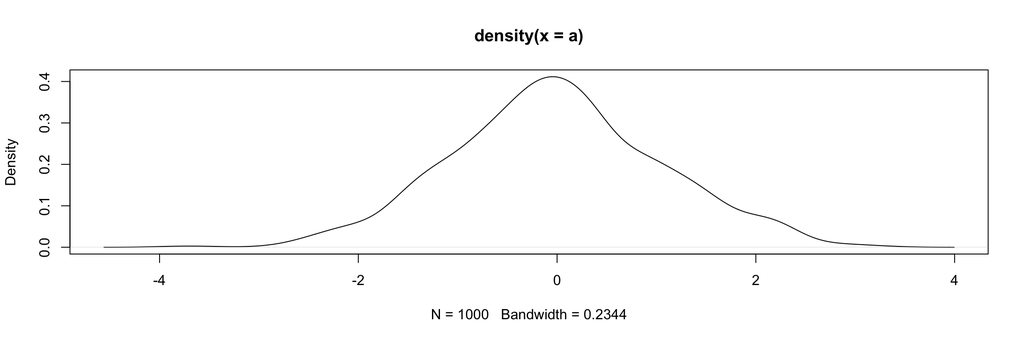

Abbildung 1.1: Dichtefunktion einer normalverteilten Zufallsvariable

```r
plot(density(a))
```

Nun können wir auf Abbildung 1.1 verweisen.

## 1.1 Zweite Überschrift

Verweise auf die oberste Überschrift:

- siehe dieser Abschnitt,
- siehe Abschnitt 1.

Man sollte auch ein bisschen Literatur zitieren. Und zwar in Klammern (Lew & Ptasznik & Wolfer 2024) aber auch im laufenden Text, das denken bestimmt auch Lew & Wolfer (2024). Mehrere Zitationen werden übrigens über ; getrennt.

### 1.1.1 Dritte Überschrift

Keine wissenschaftliche Veröffentlichung ohne Fußnoten[^1].

Eventuell will man auch eine Formel zeigen. Das geht In-Text wie in $y = x^2$ oder abgesetzt:

$$s = \sqrt{\frac{\sum_i^n{(x_i - \bar{x}})^2}{n}}$$
Wenn man Formeln allerdings referenzieren will, dann muss man sie (glaube ich) in ein entsprechendes Environment packen.

$$\begin{equation}
f(k) = \binom{n}{k} p^k(1-p)^{n-k}
\tag{1.1}
\end{equation}$$

Nun kann ich auf Formel (1.1) verweisen.

### Literaturverzeichnis

Lew, Robert & Ptasznik, Bartosz & Wolfer, Sascha. 2024. The effectiveness of ChatGPT as a lexical tool for English, compared with a bilingual dictionary and a monolingual learner’s dictionary. *Humanities and Social Sciences Communications* 11(1). 1324. DOI: https://doi.org/10.1057/s41599-024-03775-y

Lew, Robert & Wolfer, Sascha. 2024. CEFR vocabulary level as a predictor of user interest in English Wiktionary entries. *Humanities and Social Sciences Communications* 11(1). 340. DOI: https://doi.org/10.1057/s41599-024-02838-4

Ptasznik, Bartosz & Wolfer, Sascha & Lew, Robert. 2024. A Learners’ Dictionary Versus ChatGPT in Receptive and Productive Lexical Tasks. *International Journal of Lexicography* ecae011. DOI: https://doi.org/10.1093/ijl/ecae011

[^1]: Ne wirklich, man braucht immer mindestens eine Fußnote :)